# Assignment 1 - Processing GEO GSE251939

Clare Gillis

Feb 8, 2025

# Intro to the dataset

This report documents my initial processing of the dataset sourced from GEO accession GSE251939.

## Download Data

I’ll begin by downloading the dataset from GEO using the getGEO program

```r
# ==================
# Get the GEO accession
# ==================
data_set_geoid <- "GSE251939"
gse <- GEOquery::getGEO(data_set_geoid ,GSEMatrix=FALSE)
```

## Data Summary

Now let’s see what the dataset is about

```r
# ==================
# Print the title and summary of the downloaded dataset
# ==================
title <- paste0("**", gse@header$title, "**\n\n")
summary <- paste(gse@header$summary, "\n\n")
design <- gse@header$overall_design[[1]]

cat(title, summary, design)
```

**Analysis of microisolated frontal cortex excitatory layer III and V pyramidal neurons reveals a neurodegenerative phenotype in individuals with Down syndrome**

Down syndrome (DS) is the most prevalent genetic abnormality, occurring in ~1/700 live births caused by triplication of human chromosome 21 (HSA21). DS individuals have a multitude of phenotypic changes in peripheral systems and most notably, are cognitively impaired, with deficits in learning, language and memory acquisition and consolidation. Further, individuals with DS develop Alzheimer’s disease (AD) pathology during early middle-age (mid-30’s), although the underlying mechanism(s) driving this pathology onset are not well understood. Contributing to cognitive impairment in DS, morphological deficits are present in cortical lamination and distribution, with Layer III (L3) and Layer V (L5) pyramidal neurons showing reduced proliferation and a disorganized laminar structure. As such, examining cortical L3 and L5 pyramidal neurons in DS individuals with AD pathology may elucidate alternate driver mechanisms of disease onset. We examined DS and age-matched control (CTR) brains from individuals without intellectual disabilities or dementia using postmortem frontal cortex (BA9) via single population low input RNA-sequencing. We specifically targeted L3 and L5 pyramidal neurons to understand circuitry-based alterations in DS/AD individuals to elucidate mechanistic drivers of disease pathology. We show convergent and divergent gene expression changes in L3 and L5 pyramidal neurons which may underlie cognitive deficits and degenerative pathology associated with aging in the DS brain. We pinpoint alterations in HSA21 gene expression as well as a multitude of convergent differentially expressed genes (DEGs) and relevant pathways via bioinformatic inquiry in the DS brains that underlie mechanisms of degeneration. Distinctly, convergent gene expression reveals a neurotoxic phenotype, with multiple canonical pathways of dysregulation and disease functions linked to the convergent DEGs, including downregulation of the CLEAR signaling pathway and significantly increased activation of the neuroinflammation signaling pathway. We identify several target genes including mitogen activated protein kinase 1 and 3 (MAPK1/3), calcium voltage-gated channel subunit alpha1 A (CACNA1A) and superoxide dismutase 1 (SOD1), which exhibit overlap in multiple pathways and disease functions and/or display dysfunctional protein-protein network interactions for further examination. Novel targets identified by our single population approach in L3 and L5 pyramidal neurons may be drivers of the disease mechanism and therefore may be therapeutic candidates for amelioration of degenerative pathology that targets memory and executive function circuits in DS/AD.

===============================================================================

To summarize, this is a dataset of batch RNAseq data from layer 3 (L3) and 5 (L5) pyramidal neurons of individuals with Down Syndrome (DS) compared to control brains. Many people with Down Syndrom develop pathology of Alzheimer’s Disease (AD), particularily in their L3 and L5 pyramidal neurons–this makes studying the gene expression in L3 and L5 pyramidal neurons particularily interesting [1]. Before this project, I was unaware of the prevalence of AD pathology among DS individuals, so I am looking forward to delving deeper through this dataset this semester.

This dataset consists of RNA-seq data from L3 and L5 pyramidal neurons of the BA9 region of the frontal-cortices of 12 individuals with Down Syndrome, and 17 control brains [1].

# Dive deeper

## Assess

### Overview

There is a lot of information about this dataset held in the object we downloaded. Lets start by extracting some of the overview information about the dataset.

```r
# ==================
# Extract overview info about the accession
# ==================
current_gpl <- names(GPLList(gse))[1]
current_gpl_info <- GEOquery::Meta(getGEO(current_gpl))
```

The dataset I’ve selected needs to contain recent (less than 10 years old) human RNA-seq data (generally gathered through high throughput sequencing.)

Let’s check if this is true from the overview information we just extracted

```r
# ==================
# Check that the dataset fits age, species, and technology criteria
# ==================
cat(paste("Last update date:", current_gpl_info$last_update_date, "\n"))
```

```
## Last update date: Nov 05 2018
```

```r
cat(paste("Organism:", current_gpl_info$organism, "\n"))
```

```
## Organism: Homo sapiens
```

```r
cat(paste("Technology:", current_gpl_info$technology, "\n"))
```

```
## Technology: high-throughput sequencing
```

Looks good!

Now that we know the most basic criteria are met, lets take a closer look at what the dataset contains. We’ll start by checking out the names of the supplementary files.

### Suppplementary files

```r
# ==================
# Extract supplementary filenames
# ==================
sfilenames = GEOquery::getGEOSuppFiles(data_set_geoid, fetch_files = FALSE)
sfilenames$fname
```

```
## [1] "GSE251939_Layer_3_Technical_replicates.xlsx"
## [2] "GSE251939_Layer_5_Technical_replicates.xlsx"
## [3] "GSE251939_RAW.tar"
## [4] "GSE251939_count_matrix_l3.txt.gz"
## [5] "GSE251939_count_matrix_l5.txt.gz"
```

```r
# ==================
# Save the supplementary files
# ==================

# We're choosing to download the files in the current working directory
download_dir <- file.path(getwd())

# Check which of the supplementary files are missing from download_dir
missing_files <- sfilenames$fname[!unlist(
  lapply(sfilenames$fname,FUN=function(x){
  file.exists(file.path(download_dir,data_set_geoid,x)
              )
    }
  )
  )
  ]

# Download each file only if it doesn't exist yet - we don't want to download
# things more than once
if(length(missing_files) > 0){
  for(i in 1:length(missing_files)){
    #get the supplementary files
    sfiles = GEOquery::getGEOSuppFiles(data_set_geoid,
                             filter_regex = missing_files[i],
                             baseDir = download_dir,
                             fetch_files = TRUE)
    }
}
```

### Extract Count Matrices

Based on the names of the files, we can infer what some of them contain. To start, the names of GSE251939_count_matrix_l3.txt.gz and GSE251939_count_matrix_l5.txt.gz indicate that they contain the actual count matrices of our RNA seq data, with the first containing the data from L3 cells, and the second containing the data from the L5 cells. Let’s open those up and pull out the count matrices.

```r
# ==================
# Extract the RNAseq counts from the desired files
# ==================

data_filename_l3 <- sfilenames$fname[4]
data_filename_l5 <- sfilenames$fname[5]


# Layer 3 sample data ###

# Read in the counts table for layer 3 cell data
l3_ds_vs_ctl_data <- read.table(
  file.path(download_dir, data_set_geoid, data_filename_l3),
  header=TRUE,
  check.names=TRUE)

# Append _L3 to the end of layer 3 sample names to differentiate them from layer
# 5 samples
colnames(l3_ds_vs_ctl_data) <- paste0(colnames(l3_ds_vs_ctl_data), "_L3")

cat(paste(
  "Layer 3 #Genes x #Samples: ",
  dim(l3_ds_vs_ctl_data)[1],
  "x",
  dim(l3_ds_vs_ctl_data)[2],
  "\n"
  )
  )
```

```
## Layer 3 #Genes x #Samples:  61906 x 46
```

```r
# Layer 5 sample data ###

# Read in the counts table for layer 5 cell data
l5_ds_vs_ctl_data <- read.table(
  file.path(download_dir, data_set_geoid, data_filename_l5),
  header=TRUE,
  check.names=TRUE)

# Append _L5 to the end of layer 5 sample names
colnames(l5_ds_vs_ctl_data) <- paste0(colnames(l5_ds_vs_ctl_data), "_L5")

cat(paste(
  "Layer 5 #Genes x #Samples: ",
  dim(l5_ds_vs_ctl_data)[1],
  "x",
  dim(l5_ds_vs_ctl_data)[2],
  "\n"
  )
  )
```

```
## Layer 5 #Genes x #Samples:  61906 x 36
```

```r
# All sample data ###

# Combine the layer 3 and layer 5 count matrices
ds_vs_ctl_data <- cbind(l3_ds_vs_ctl_data, l5_ds_vs_ctl_data)

cat(paste(
  "Total #Genes x #Samples: ",
  dim(ds_vs_ctl_data)[1],
  "x",
  dim(ds_vs_ctl_data)[2],
  "\n"
  )
  )
```

```
## Total #Genes x #Samples:  61906 x 82
```

The count matrices contain data for 61906 genes which is excellent coverage, but the number of samples is odd… In the summary, we’re told that the dataset contains samples from 29 people (12 DS, 17 CTR) - why are we seeing 46 Layer 3 samples and 36 Layer 5 samples? It’s likely these are from technical replicates, so let’s take a look at how the creators of the database handled these by extracting some information about data processing and the samples.

```r
# ==================
# Extract data processing and sample information
# ==================
cat(paste(gse@gsms[["GSM7990296"]]@header[["extract_protocol_ch1"]][[2]], "\n\n"))
```

```
## Each RNA Sample was split into two technical replicates before library preparation using SMARTer Stranded Total RNA-Seq kit-Pico input Mammalian. Dual Index primers and UMIs were unique to each technical replicate.  Fragmentation was performed as needed based on RIN/DV200 values according to manu…
```

```r
cat(paste(gse@gsms[["GSM7990296"]]@header[["extract_protocol_ch1"]][[3]], "\n\n"))
```

```
## RNA-seq samples were quantified (Agilent Tapestation, D1000 DNA Assay), and samples below 2 nM of the library were excluded. Samples were pooled in equimolar concentrations and assayed on Illumina NovaSeq 6000 S1 and S2 flow cells using the 100-cycle paired-end read protocol at the NYUGSOM Genome…
```

```r
cat(paste(gse@gsms[[1]]@header$data_processing[[2]], "\n\n"))
```

```
## Trimmed sequence reads were aligned to the reference  genome (GRCh38) using STAR Aligner. Gene counts were extracted using RSEM.
```

Here the authors explain that they combined each of the two technical replicates per sample into one - this would make us expect that there would be exactly 29 samples per layer, but this is not the case. Perhaps there is some more information in the supplementary files.

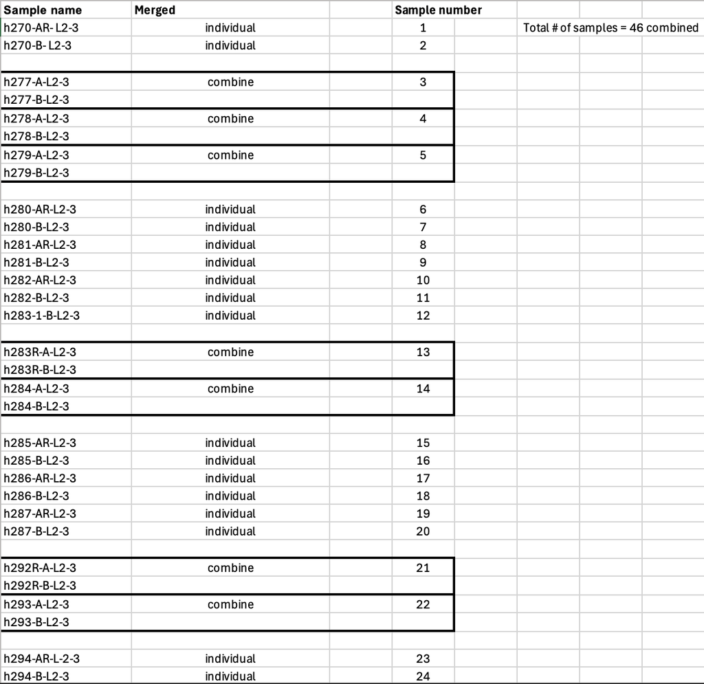

Lines 1-38 of GSE251939_Layer_3_Technical_replicates.xlsx. This file outlines which of the samples of layer 3 that met the quality threshold were combined into one sample and which remained independent samples

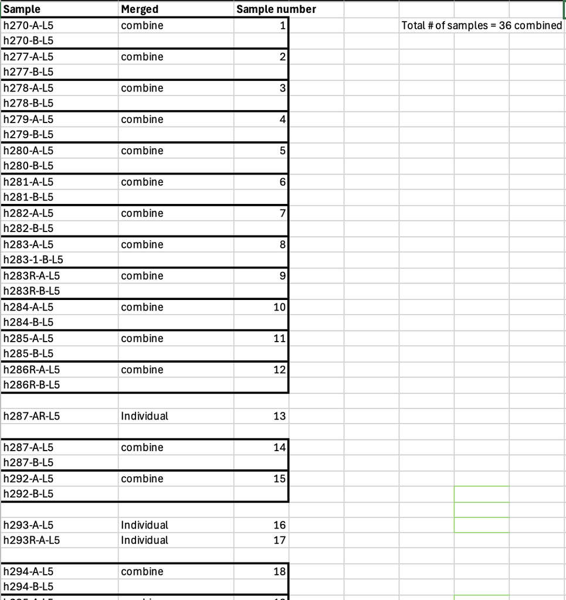

Lines 1-38 of GSE251939_Layer_5_Technical_replicates.xlsx. This file outlines which of the samples of layer 5 that met the quality threshold were combined into one sample and which remained independent samples

### Combine technical replicates

Aha! What appears to have happened, is that the authors failed to standardize their protocol on combining replicate samples. It is likely they extracted samples that did not meet their quality threshold, so they repeated these samples and added an R to their name (albeit without standardized naming conventions.) For some of these replicates, they combined them with an original technical replicate that met the threshold, while for others, they left them as individual samples. Moreover, when there resulted more than two replicates that met the threshold, they combined only two into one sample, leaving at least one as an individual. For smoother data handling, I will combine all technical replicates.

```r
# ==================
# Combine technical replicates
# ==================

# Extract the sample ids from the original sample names
sampleIDs <- sub("(h\\d+).*?_L(\\d+)", "\\1_L\\2", colnames(ds_vs_ctl_data))

# Combine replicates using row-wise means for sample
combined_replicates <- as.data.frame(sapply(unique(sampleIDs), function(g) {
  rowMeans(ds_vs_ctl_data[, sampleIDs == g, drop = FALSE], na.rm = TRUE)
}))

# Assign new columns names as the sample ids
colnames(combined_replicates) <- unique(sampleIDs)

# Print new numbers of genes and samples after combining technical replicates
cat("After combining replicates:\n")
```

```
## After combining replicates:
```

```r
cat(paste(
  "Layer 3 #Genes x #Samples: ",
  dim(combined_replicates)[1],
  "x",
  sum(grepl("L3$", colnames(combined_replicates))),
  "\n"
  )
  )
```

```
## Layer 3 #Genes x #Samples:  61906 x 29
```

```r
cat(paste(
  "Layer 5 #Genes x #Samples: ",
  dim(combined_replicates)[1],
  "x",
  sum(grepl("L5$", colnames(combined_replicates))),
  "\n"
  )
  )
```

```
## Layer 5 #Genes x #Samples:  61906 x 29
```

```r
cat(paste(
  "Total replicates #Genes x #Samples: ",
  dim(combined_replicates)[1],
  "x",
  dim(combined_replicates)[2],
  "\n"
  )
  )
```

```
## Total replicates #Genes x #Samples:  61906 x 58
```

## Map to HUGO symbols

Let’s now take a quick look at the count matrix itself.

```r
# ==================
# Snapshot of the count matrix
# ==================

kable(combined_replicates[1:7,1:10], format = "html")
```

|  | h270_L3 | h277_L3 | h278_L3 | h279_L3 | h280_L3 | h281_L3 | h282_L3 | h283_L3 | h284_L3 | h285_L3 |
| --- | --- | --- | --- | --- | --- | --- | --- | --- | --- | --- |
| ENSG00000000003 | 6.5 | 18 | 5 | 9 | 3.50 | 2.0 | 5.00 | 5.0 | 13 | 2.500 |
| ENSG00000000005 | 0.0 | 0 | 0 | 5 | 0.00 | 0.0 | 0.50 | 0.0 | 0 | 0.000 |
| ENSG00000000419 | 70.5 | 148 | 99 | 44 | 30.50 | 51.5 | 41.00 | 50.5 | 133 | 35.500 |
| ENSG00000000457 | 30.0 | 77 | 44 | 7 | 14.50 | 20.0 | 23.00 | 12.5 | 49 | 11.500 |
| ENSG00000000460 | 2.5 | 3 | 11 | 3 | 3.50 | 8.5 | 1.00 | 2.5 | 8 | 3.500 |
| ENSG00000000938 | 0.0 | 4 | 9 | 6 | 2.00 | 2.5 | 0.00 | 1.5 | 10 | 0.000 |
| ENSG00000000971 | 4.5 | 86 | 42 | 31 | 7.24 | 6.5 | 9.26 | 15.0 | 13 | 2.975 |

The genes seen on the left are denoted by ensembl IDs, however we would like to use HUGO gene symbols. Thankfully, it looks like the ensembl IDs are gene IDs (based on the G in ENSG at the beginning of each) making them easy to map to HUGO symbols.

To map our ensembl gene IDs to HUGO symbols, we first need to choose the right dataset.

```r
# ==================
# Choose human gene
# ==================

# Look at the archived versions of ensembl - remeber our dataset was last
# updated in Nov 2018, so lets use an ensembl version closer to then
biomaRt::listEnsemblArchives()[1:20,]
```

```
##              name     date                                 url version
## 1  Ensembl GRCh37 Feb 2014          https://grch37.ensembl.org  GRCh37
## 2     Ensembl 113 Oct 2024 https://oct2024.archive.ensembl.org     113
## 3     Ensembl 112 May 2024 https://may2024.archive.ensembl.org     112
## 4     Ensembl 111 Jan 2024 https://jan2024.archive.ensembl.org     111
## 5     Ensembl 110 Jul 2023 https://jul2023.archive.ensembl.org     110
## 6     Ensembl 109 Feb 2023 https://feb2023.archive.ensembl.org     109
## 7     Ensembl 108 Oct 2022 https://oct2022.archive.ensembl.org     108
## 8     Ensembl 107 Jul 2022 https://jul2022.archive.ensembl.org     107
## 9     Ensembl 106 Apr 2022 https://apr2022.archive.ensembl.org     106
## 10    Ensembl 105 Dec 2021 https://dec2021.archive.ensembl.org     105
## 11    Ensembl 104 May 2021 https://may2021.archive.ensembl.org     104
## 12    Ensembl 103 Feb 2021 https://feb2021.archive.ensembl.org     103
## 13    Ensembl 102 Nov 2020 https://nov2020.archive.ensembl.org     102
## 14    Ensembl 101 Aug 2020 https://aug2020.archive.ensembl.org     101
## 15    Ensembl 100 Apr 2020 https://apr2020.archive.ensembl.org     100
## 16     Ensembl 99 Jan 2020 https://jan2020.archive.ensembl.org      99
## 17     Ensembl 98 Sep 2019 https://sep2019.archive.ensembl.org      98
## 18     Ensembl 80 May 2015 https://may2015.archive.ensembl.org      80
## 19     Ensembl 77 Oct 2014 https://oct2014.archive.ensembl.org      77
## 20     Ensembl 75 Feb 2014 https://feb2014.archive.ensembl.org      75
##    current_release
## 1
## 2                *
## 3
## 4
## 5
## 6
## 7
## 8
## 9
## 10
## 11
## 12
## 13
## 14
## 15
## 16
## 17
## 18
## 19
## 20
```

```r
ensembl_2019_version <- "https://sep2019.archive.ensembl.org"

# Get the ensembl datasets
ensembl_2019 <- biomaRt::useMart("ensembl", host = ensembl_2019_version)
datasets <- biomaRt::listDatasets(ensembl_2019)

# List the datasets that contain "sapiens" in their name - these are the
# human datasets
kable(head(datasets[grep(datasets$dataset, pattern = "sapiens"),]), format = 'html')
```

|  | dataset | description | version |
| --- | --- | --- | --- |
| 85 | hsapiens_gene_ensembl | Human genes (GRCh38.p13) | GRCh38.p13 |

Great! It looks like there’s only one dataset of human genes to pick from.

```r
# ==================
# Select human gene dataset
# ==================
ensembl_2019 = biomaRt::useDataset("hsapiens_gene_ensembl",mart=ensembl_2019)
```

Now let’s take a look at the filters we can use to search the dataset (this is to figure out which search terms to use when mapping our gene IDs to HUGO symbols.)

```r
# ==================
# List filters
# ==================
biomart_human_filters <- biomaRt::listFilters(ensembl_2019)

# List the filters containing the word "ensembl" or "hgnc"
kable(biomart_human_filters[grep(biomart_human_filters$name,pattern="ensembl|hgnc"),], format="html")
```

|  | name | description |
| --- | --- | --- |
| 13 | with_clone_based_ensembl_gene | With Clone-based (Ensembl) gene ID(s) |
| 14 | with_clone_based_ensembl_transcript | With Clone-based (Ensembl) transcript ID(s) |
| 25 | with_hgnc | With HGNC Symbol ID(s) |
| 50 | with_hgnc_trans_name | With Transcript name ID(s) |
| 57 | ensembl_gene_id | Gene stable ID(s) [e.g. ENSG00000000003] |
| 58 | ensembl_gene_id_version | Gene stable ID(s) with version [e.g. ENSG00000000003.15] |
| 59 | ensembl_transcript_id | Transcript stable ID(s) [e.g. ENST00000000233] |
| 60 | ensembl_transcript_id_version | Transcript stable ID(s) with version [e.g. ENST00000000233.10] |
| 61 | ensembl_peptide_id | Protein stable ID(s) [e.g. ENSP00000000233] |
| 62 | ensembl_peptide_id_version | Protein stable ID(s) with version [e.g. ENSP00000000233.5] |
| 63 | ensembl_exon_id | Exon ID(s) [e.g. ENSE00000327880] |
| 68 | clone_based_ensembl_gene | Clone-based (Ensembl) gene ID(s) [e.g. ABBA01000933.1] |
| 69 | clone_based_ensembl_transcript | Clone-based (Ensembl) transcript ID(s) [e.g. ABBA01000933.1-201] |
| 82 | hgnc_id | HGNC ID(s) [e.g. HGNC:100] |
| 83 | hgnc_symbol | HGNC symbol(s) [e.g. A1BG] |
| 111 | hgnc_trans_name | Transcript name ID(s) [e.g. A1BG-201] |

```r
# ==================
# Remove version numbers
# ==================

# Check how many gene IDs have a version number
numWithVersion <- sum(grepl("\\.", rownames(combined_replicates)))
cat(paste("Number of gene IDs with version number:", numWithVersion))
```

```
## Number of gene IDs with version number: 46
```

```r
# Extract only the Gene IDs (the part before the period)
geneIDs <- sub("\\..*", "", rownames(combined_replicates))
```

```r
# ==================
# Search for HUGO symbols by enesmbl Gene IDs
# ==================

# check to see if there is a file containing the conversion between ensembl gene
# IDs and HUGO gene symbols
conversion_stash_2019 <- "id_conversion_2019.rds"
if(file.exists(conversion_stash_2019)){
  id_conversion <- readRDS(conversion_stash_2019)
} else {

  # Extract the mapping of gene IDs to HUGO symbols for all of the genes in
  # our dataset, then save them in a file
  id_conversion <- biomaRt::getBM(attributes =
                           c("ensembl_gene_id","hgnc_symbol"),
                         filters = c("ensembl_gene_id"),
                         values = geneIDs,
                         mart = ensembl_2019)
  saveRDS(id_conversion, conversion_stash_2019)
}

# Create a new column in combined_replicates with cleaned gene IDs
combined_replicates$gene_id_clean <- sub("\\..*", "", rownames(combined_replicates))

# Add the HUGO symbols to our data matrix
combined_replicates_annot <- merge(
  id_conversion,
  combined_replicates,
  by.x = 1,
  by.y = "gene_id_clean",
  all.y=TRUE
)
colnames(combined_replicates_annot)[colnames(combined_replicates_annot) == "hgnc_symbol"] <- "hgnc_symbol_2019"

cat(paste("Genes in our dataset:", nrow(combined_replicates), "\n"))
```

```
## Genes in our dataset: 61906
```

```r
cat(paste("Gene IDs in our dataset mapped to HUGO symbols:",
          length(
            which(combined_replicates$gene_id_clean %in% id_conversion$ensembl_gene_id)), "\n"))
```

```
## Gene IDs in our dataset mapped to HUGO symbols: 60441
```

```r
cat(paste(
  "Gene IDs in our dataset missing HUGO symbols:",
  nrow(combined_replicates) - length(
    which(combined_replicates$gene_id_clean %in% id_conversion$ensembl_gene_id)), "\n"))
```

```
## Gene IDs in our dataset missing HUGO symbols: 1465
```

Many genes are missing HUGO symbols - it is possible these genes have been annotated since our dataset was last updated. Let’s try to map them to HUGO symbols using the most recent release of ensembl on biomaRt

```r
# ==================
# Search for HUGO symbols by enesmbl Gene IDs - 2024 Ensembl
# ==================

# Select the current ensembl release
ensembl_2024_version <- "https://oct2024.archive.ensembl.org"
ensembl_2024 <- biomaRt::useMart("ensembl", host = ensembl_2024_version)
datasets <- biomaRt::listDatasets(ensembl_2024)

# Select the human dataset
ensembl_2024 = biomaRt::useDataset("hsapiens_gene_ensembl",mart=ensembl_2024)

# check to see if there is a file containing the conversion between ensembl gene
# IDs and HUGO gene symbols
conversion_stash_2024 <- "id_conversion_2024.rds"
if(file.exists(conversion_stash_2024)){
  id_conversion <- readRDS(conversion_stash_2024)
} else {
  # Extract the mapping of gene IDs to HUGO symbols for all of the genes in
  # our dataset, then save them in a file
  id_conversion <- biomaRt::getBM(attributes =
                           c("ensembl_gene_id","hgnc_symbol"),
                         filters = c("ensembl_gene_id"),
                         values = geneIDs,
                         mart = ensembl_2024)
  saveRDS(id_conversion, conversion_stash_2024)
}

# Add the HUGO symbols to our data matrix
combined_replicates_annot <- merge(
  id_conversion,
  combined_replicates_annot,
  by.x = 1,
  by.y = "ensembl_gene_id",
  all.y=TRUE
)
colnames(combined_replicates_annot)[colnames(combined_replicates_annot) == "hgnc_symbol"] <- "hgnc_symbol_2024"

num_with_symbol <- sum(
            !is.na(combined_replicates_annot$hgnc_symbol_2024) |
              !is.na(combined_replicates_annot$hgnc_symbol_2019))

cat(paste("Genes in our dataset:", nrow(combined_replicates_annot), "\n"))
```

```
## Genes in our dataset: 61913
```

```r
cat(paste("Gene IDs in our dataset mapped to HUGO symbols:", num_with_symbol, "\n"))
```

```
## Gene IDs in our dataset mapped to HUGO symbols: 61799
```

```r
cat(paste(
  "Gene IDs in our dataset missing HUGO symbols:",
  nrow(combined_replicates) - num_with_symbol, "\n"))
```

```
## Gene IDs in our dataset missing HUGO symbols: 107
```

Much better! Now let’s take a look at those unmapped gene IDs and see why they aren’t mapped to HUGO symbols

```r
# ==================
# Display entries without HUGO symbol
# ==================
kable(combined_replicates_annot[which(is.na(combined_replicates_annot$hgnc_symbol_2024) & is.na(combined_replicates_annot$hgnc_symbol_2019))[1:5],1:5], type="html")
```

|  | ensembl_gene_id | hgnc_symbol_2024 | hgnc_symbol_2019 | h270_L3 | h277_L3 |
| --- | --- | --- | --- | --- | --- |
| 60452 | ENSG00000288526 | NA | NA | 0.0 | 0 |
| 60457 | ENSG00000288531 | NA | NA | 2.0 | 10 |
| 60476 | ENSG00000288553 | NA | NA | 0.5 | 0 |
| 60477 | ENSG00000288554 | NA | NA | 0.0 | 0 |
| 60488 | ENSG00000288565 | NA | NA | 2.5 | 5 |

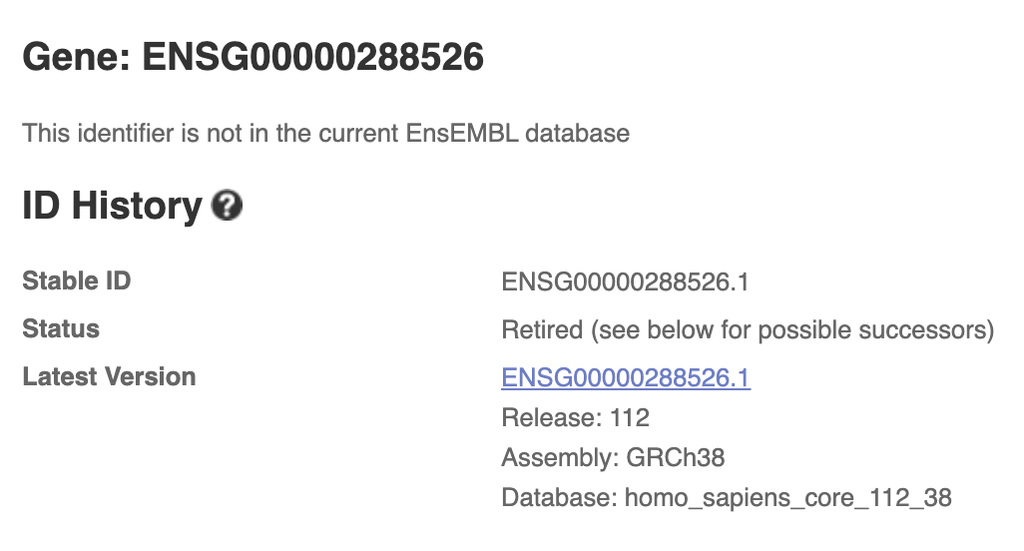

Snapshot of the Ensembl page for ENSG00000288526 [2]

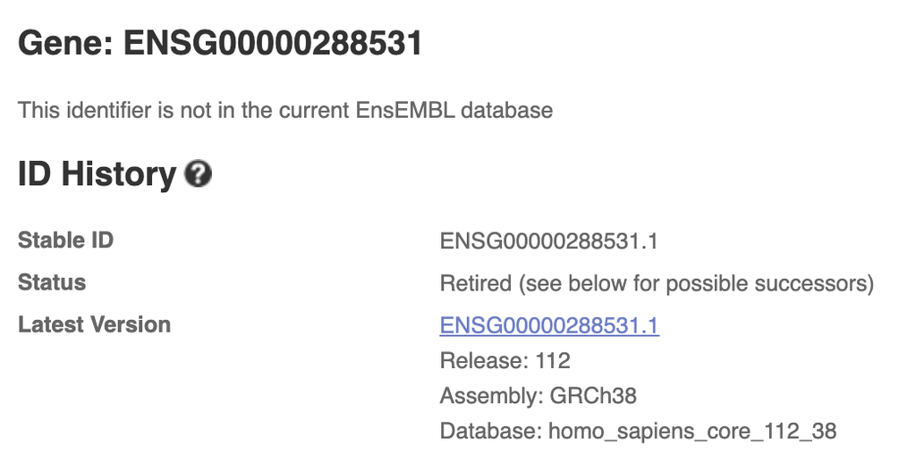

Snapshot of the Ensembl page for ENSG00000288531 [2]

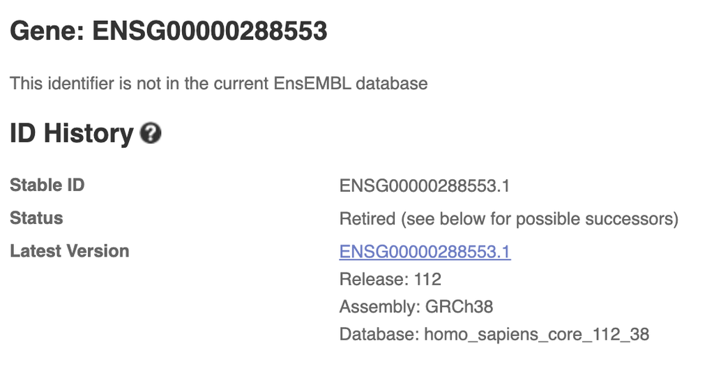

Snapshot of the Ensembl page for ENSG00000288553 [2]

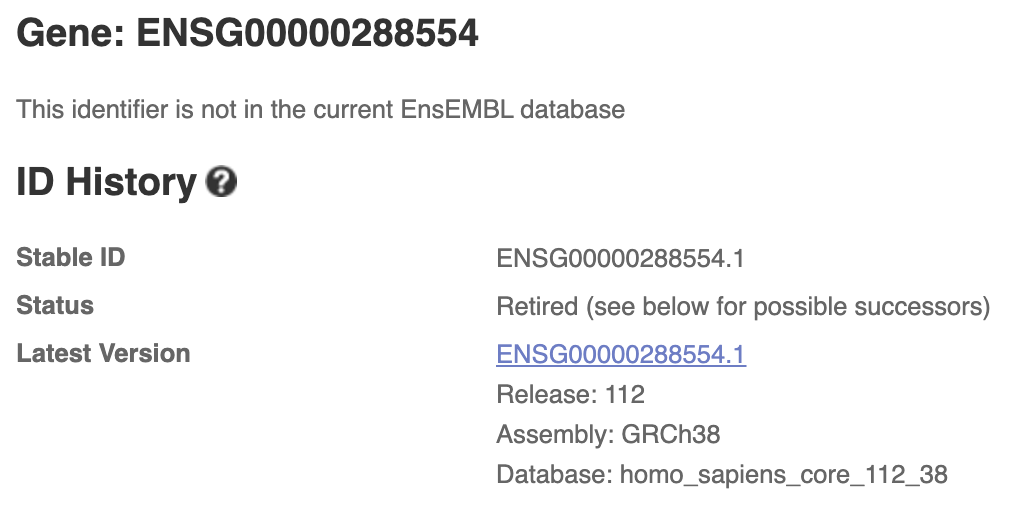

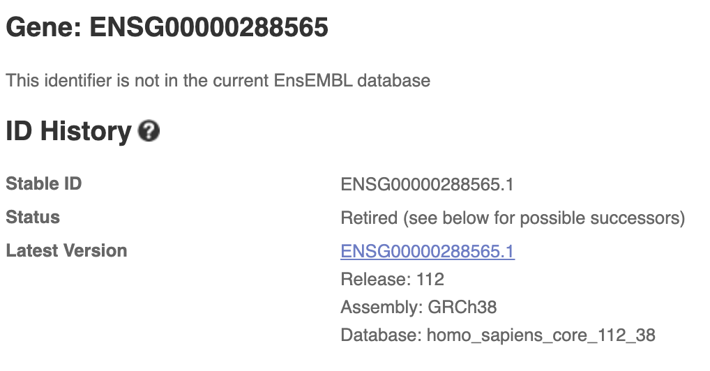

Based on the first five genes, these gene IDs have been retired, so we will remove them from our dataset.

```r
# ==================
# Remove entries without HUGO symbol
# ==================

clean_data <- combined_replicates_annot[
  !is.na(combined_replicates_annot$hgnc_symbol_2024) | !is.na(combined_replicates_annot$hgnc_symbol_2019),
]
```

Since we mapped our gene IDs to HUGO symbols using ensembl from 2019 and 2024, there may be some discrepancies. Lets map each entry to its the HUGO symbol from 2024 if available, and fall back on the 2019 symbol whenever necessary.

```r
# ==================
# Consolidate HUGO symbols
# ==================

# Take hgnc_symbol_2024 evenever possible, if not, take hgnc_symbol_2019
# Remove hgnc_symbol_2024 and hgnc_symbol_2019
clean_data <- clean_data %>%
  mutate(hgnc_symbol = coalesce(hgnc_symbol_2024, hgnc_symbol_2019)) %>%
  select(-hgnc_symbol_2024, -hgnc_symbol_2019)
```

Finally, lets make sure that each symbol and gene ID is unique.

```r
# ==================
# Search for duplicate gene IDs and symbols
# ==================

cat(paste(
  "Duplicate hgnc_symbol:",
  sum(duplicated(clean_data$hgnc_symbol)),
  "\n"
  )
  )
```

```
## Duplicate hgnc_symbol: 20677
```

```r
cat(paste(
  "Duplicate ensembl_gene_id:",
  sum(duplicated(clean_data$ensembl_gene_id)),
  "\n"
  )
  )
```

```
## Duplicate ensembl_gene_id: 52
```

```r
# ==================
# Remove duplicate ensembl IDs and hgnc symbols
# ==================

# Take the first HUGO symbol for each set of duplicated ensembl IDs
clean_data <- clean_data[!duplicated(clean_data$ensembl_gene_id), ]

# Take the first ensembl gene ID for each set of duplicted HUGO symbols
clean_data <- clean_data[!duplicated(clean_data$hgnc_symbol), ]

# Map the rows to only HUGO symbols
rownames(clean_data) <- clean_data$hgnc_symbol
clean_data <- clean_data %>%
  select(-ensembl_gene_id, -hgnc_symbol)
```

Great! Now we have a dataset of RNA-Seq data where each row corresponds to a gene represented by a unique HUGO symbol! We can now move onto normalization.

# Normalize

We’ll start by taking a closer look at our samples which can give us some important parameters for normalization.

```r
# ==================
# Extract samples and count them by layer and diagnosis
# ==================

# Extract all samples
list_of_samples <- gse@gsms

# Get the name and characteristics of each sample
sample_type <- do.call(rbind, lapply(list_of_samples,
                                     FUN=function(x){
                                       c(x@header$title,
                                         x@header$characteristics_ch1)
                                       }
                                     )
                       )
colnames(sample_type) <- c("title", "cell type", "diagnosis", "layer")
sample_type[,"cell type"] <- gsub(sample_type[, "cell type"],
                                  pattern = "cell type: ",
                                  replacement = "")
sample_type[,"diagnosis"] <- gsub(sample_type[, "diagnosis"],
                                  pattern = "diagnosis: ",
                                  replacement = "")
sample_type[,"layer"] <- gsub(sample_type[, "layer"],
                                  pattern = "layer: ",
                                  replacement = "")

# Extract sample IDs from the title (ex. 'h270' from 'FCPN, Layer3,CTR, h270B_Layer3')
redundant_sample_type_dt <- data.table::data.table(sample_type)
redundant_sample_type_dt[, "sampleID"] <- sub(".*(h\\d+).*", "\\1", redundant_sample_type_dt$title)

# Remove all technical replicates
sample_type_dt <- redundant_sample_type_dt[, .SD[1], by = .(sampleID, layer)]

# Count the samples by layer and diagnosis
sample_counts <- sample_type_dt[, .(count = .N), by = .(layer, diagnosis)]
sample_counts
```

```
##     layer diagnosis count
## 1: Layer3       CTR    17
## 2: Layer3        DS    12
## 3: Layer5       CTR    17
## 4: Layer5        DS    12
```

The fewest samples we have for a category is 12 - this will be important for our CPM normailization.

## CPM

We will start our normalization by removing counts that appear in very few samples. These are likely due to technical error and will only add noise to our dataset rather than statistically significant context about differential expression.

We will keep data from any genes that are expressed in at least 10 samples to ensure that genes expressed in only the smallest group (N=12) are detected.

```r
# ==================
# Filter by CPM
# ==================

# Convert the count data table to a matrix
data_matrix <- as.matrix(clean_data)

# Filter based on counts per million (CPM)
# Keep genes expressed in at least 10 samples to ensure genes expressed only in
# the smallest group (N=12) are detected
min_num_samples <- 10
keep <- rowSums(edgeR::cpm(data_matrix) > 1) > min_num_samples
filtered_data_matrix <- data_matrix[keep,]
```

Let’s take a look at our expression data before and after CPM normalization

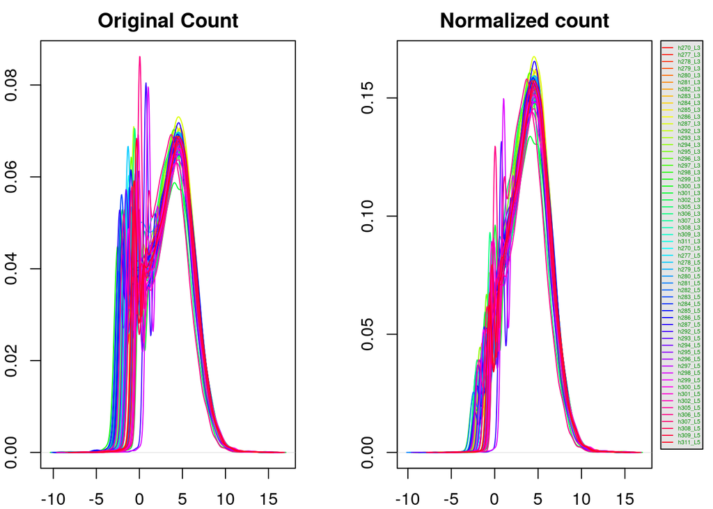

Excellent! The new curve is much smoother, indicating less noisy data. We’ll now move on to normalizing using the TMM approach.

## TMM

TMM scales RNA-seq data to account for varied library sizes. This is useful for making comparisons between samples more reliable when expression varies between them due to technical variablility like differing sequencing depth [3].

Lets apply TMM notmalization to our dataset.

```r
# ==================
# Apply TMM normalization
# ==================

sample_type_df = as.data.frame(sample_type, stringsAsFactors = FALSE)

# Apply TMM to the data
d = edgeR::DGEList(counts=filtered_data_matrix,
            groups = factor(sample_type_df$layer, sample_type_df$diagnosis))
d = edgeR::calcNormFactors(d)

normalized_counts <- edgeR::cpm(d)
```

Let’s take a look at our data before and after TMM normalization. We can use various graphing techniques to understand our data in different ways. First we’ll try a smooth line plot.

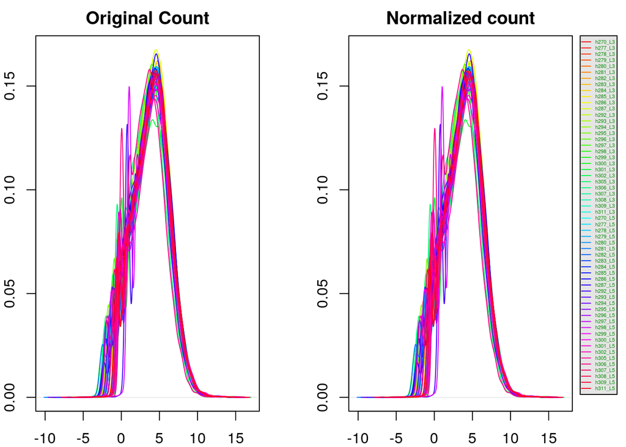

```r
# ==================
# Plot TMM and non-TMM counts - Smooth Line
# ==================

# Pre Normalization ####################################

# Set up the plotting area for two plots side by side
par(mfrow = c(1, 2), mar = c(2, 2, 2, 3))


# Plot the filtered (not TMM normalized) data ###

# Calculate the limits across all the samples
xlim <- range(sapply(cpm_counts_density, function(d) d$x))
ylim <- range(sapply(cpm_counts_density, function(d) d$y))

# Color and line style settings
cols <- rainbow(length(cpm_counts_density))
ltys <- rep(1, length(cpm_counts_density))

# Initialize the plot
plot(cpm_counts_density[[1]], xlim = xlim, ylim = ylim, type = "n",
     ylab = "Smoothing density of log2-CPM", main = "Original Count", cex.lab = 0.8)

# Plot each density line
for (i in 1:length(cpm_counts_density)) {
  lines(cpm_counts_density[[i]], col = cols[i])
}


# TMM normalized data ##################

tmm_counts_density <- apply(log2(edgeR::cpm(normalized_counts)), 2, density)

# Calculate the limits across all the samples for normalized counts
xlim <- range(sapply(tmm_counts_density, function(d) d$x))
ylim <- range(sapply(tmm_counts_density, function(d) d$y))

# Plot the normalized count data density
plot(tmm_counts_density[[1]], xlim = xlim, ylim = ylim, type = "n",
     ylab = "Smoothing density of log2-CPM", main = "Normalized count", cex.lab = 0.8)

# Plot each density line
for (i in 1:length(tmm_counts_density)) {
  lines(tmm_counts_density[[i]], col = cols[i])
}


# Add the combined legend outside the plotting region
par(xpd = TRUE)  # Allow plotting outside the plot area
legend("topright",
       legend = colnames(normalized_counts),
       col = cols,
       lty = ltys,
       cex = 0.34,
       border = "blue",
       text.col = "green4",
       merge = TRUE,
       bg = "gray90",
       ncol = 1,  # Arrange the legend in one column
       inset = c(-0.2, 0))  # Move the legend outside the plot
```

```r
par(xpd = FALSE)  # Restore normal plotting behavior
```

Our dataset does not appear to have changed much after TMM normalization. This is good - it suggests that differences in library size and composition between samples were minimal, indicating technical consistency in our data.

Now, lets try a box plot.

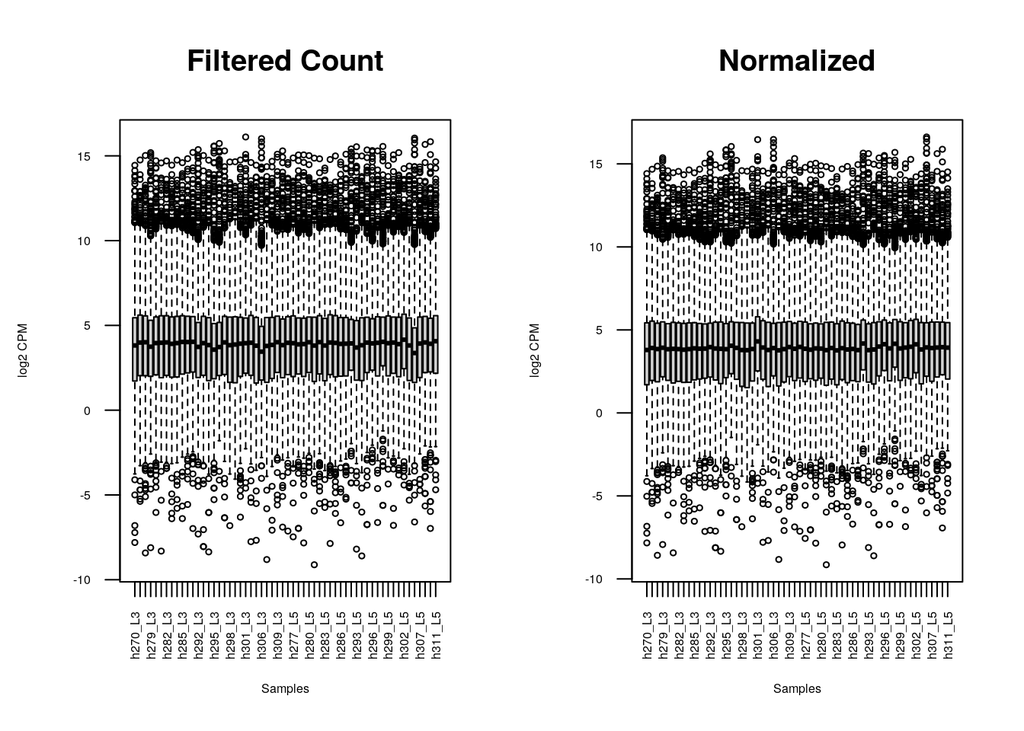

```r
# ==================
# Plot TMM and non-TMM counts - Box Plot
# ==================

# Set up the plotting area for two plots side by side
par(mfrow=c(1,2))

# Plot the filtered (not yet normalized) data
log_filtered_counts <- log2(edgeR::cpm(filtered_data_matrix))
log_filtered_counts[is.infinite(log_filtered_counts)] <- NA  # Replace -Inf with NA

boxplot(log_filtered_counts, xlab = "Samples", ylab = "log2 CPM",
        las = 2, cex = 0.5, cex.lab = 0.5,
        cex.axis = 0.5, main = "Filtered Count")
# Draw the median
abline(h = median(apply(log_filtered_counts, 2, median)),
       col = "red", lwd = 0.6, lty = "dashed")

# Plot the normalized data
log_norm_counts <- log2(normalized_counts)
log_norm_counts[is.infinite(log_norm_counts)] <- NA         # Replace -Inf with NA
boxplot(log_norm_counts, xlab = "Samples", ylab = "log2 CPM",
        las = 2, cex = 0.5, cex.lab = 0.5,
        cex.axis = 0.5, main = "Normalized")
# Draw the median
abline(h = median(apply(log_norm_counts, 2, median)),
       col = "red", lwd = 0.6, lty = "dashed")
```

Like the smooth line plot, little appears to have changed. Looks good!

Finally, lets look at the distance between our data using an MDS plot.

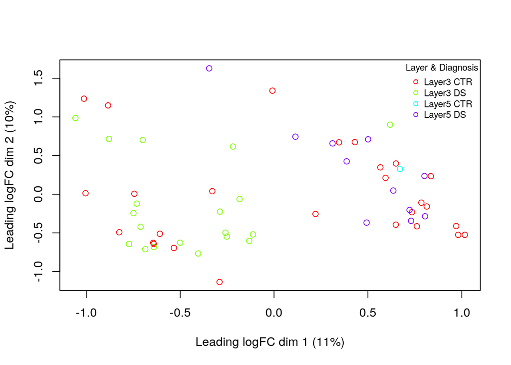

```r
# ==================
# Plot TMM and non-TMM counts - MDS PLot
# ==================

# Define colors for different combinations of layer & diagnosis
unique_groups <- unique(paste(sample_type_df$layer, sample_type_df$diagnosis))
color_map <- setNames(rainbow(length(unique_groups)), unique_groups)

# Generate MDS plot with colors by layer & diagnosis
limma::plotMDS(d,
               labels = NULL,
               pch = 1,
               col = color_map[paste(sample_type_df$layer, sample_type_df$diagnosis)])

# Add legend
legend("topright",
       legend = unique_groups,
       pch = 1,
       col = color_map,
       title = "Layer & Diagnosis",
       bty = 'n', cex = 0.75)
```

# Conclusion

We’ve gone through the steps of downloading, exploring, cleaning, and normalizing an RNA-seq dataset from GEO! To download our dataset to the current working directory, we will do the following.

```r
# ==================
# Download dataset
# ==================

# Save the cleaned RNA-seq data as a tab-delimited file
write.table(clean_data, file = "GSE251939_counts_clean_norm.txt", sep = "\t",
            row.names = FALSE, col.names = TRUE)
```

#### Why is the dataset of interest to you?

Before finding this dataset, I was unaware of the connection between Down Syndrome and Alzheimer’s Disease. Many people with Down Syndrome develop Alzheimer’s pathology, norably in their L3 and L5 pyramidal neurons from the frontal cortex [1]. This RNAseq dataset of L3 and L5 pyramidal neurons from individuals with Down Syndrome sets up an interesting analysis. There will inevitably be differential expression among genes from chromosome 21, but are these the only differentially expressed genes in these conditions? Is differential expression of chromosome 21 genes solely responsible for the Alzheimer’s pathology found in individuals with Down Syndrome?

#### What are the control and test conditions of the dataset?

Test: Samples from brains of individuals with Down Syndrome (42-67 years old)

Control: Samples from brains of control brains (individuals of similar age to the Down Syndrome samples, without Down Syndrome)

#### How many samples in each of the conditions of your dataset?

12 Down Syndrome samples (6M/6F), 17 control samples (9M/8F).

#### Were there expression values that were not unique for specific genes? How did you handle these?

After mapping the ensembl gene IDs that represented each row to a HUGO symbol, I found that there were 52 duplicated ensembl gene IDs and 20677 duplicate HUGO symbols. These were removed by selecting only the first out of all groups of duplicates.

#### Were there expression values that could not be mapped to current HUGO symbols?

There were 107 expression values that could not be mapped to any HUGO symbols since they were represented by retured ensembl gene IDs.

#### Were there any outliers in your dataset? How were they handled in the originating paper? How many outliers were removed?

I did not find any significant outliers based on expression, however, some ensembl gene IDs that were used to represent genes in the dataset were retired. I removed expression data for genes with retired ensembl gene IDs.

#### How did you handle replicates?

I combined technical replicates into one replicate per sample by averaging expression data across replicates.

#### What is the final coverage of your dataset?

The dataset covers 18027 genes.

# References

1. Alldred MJ, Ibrahim KW, Pidikiti H, Chiosis G, Mufson EJ, Stutzmann GE, et al. [Down syndrome frontal cortex layer III and layer v pyramidal neurons exhibit lamina specific degeneration in aged individuals.](https://doi.org/10.1186/s40478-024-01891-z) Acta neuropathologica communications. 2024;12:182.

2. Harrison PW, Amode MR, Austine-Orimoloye O, Azov AG, Barba M, Barnes I, et al. [Ensembl 2024](https://doi.org/10.1093/NAR/GKAD1049). Nucleic Acids Research. 2024;52:D891–9.

3. Robinson MD, Oshlack A. [A scaling normalization method for differential expression analysis of RNA-seq data](https://doi.org/10.1186/GB-2010-11-3-R25/FIGURES/3). Genome Biology. 2010;11:1–9.

4. R Core Team. [R: A language and environment for statistical computing](https://www.R-project.org/). Vienna, Austria: R Foundation for Statistical Computing; 2023.

5. Gentleman R, Carey V, Morgan M, Falcon S. [Biobase: Base functions for bioconductor](https://doi.org/10.18129/B9.bioc.Biobase). 2023.

6. Team TBD. [BiocGenerics: S4 generic functions used in bioconductor](https://doi.org/10.18129/B9.bioc.BiocGenerics). 2023.

7. Durinck S, Huber W. [biomaRt: Interface to BioMart databases (i.e. ensembl)](https://doi.org/10.18129/B9.bioc.biomaRt). 2023.

8. Wickham H, François R, Henry L, Müller K, Vaughan D. [Dplyr: A grammar of data manipulation](https://dplyr.tidyverse.org). 2023.

9. Chen Y, Lun AT, McCarthy DJ, Chen L, Ritchie ME, Phipson B, et al. [edgeR: Empirical analysis of digital gene expression data in r](https://doi.org/10.18129/B9.bioc.edgeR). 2023.

10. Davis S. [GEOquery: Get data from NCBI gene expression omnibus (GEO)](https://doi.org/10.18129/B9.bioc.GEOquery). 2023.

11. Wickham H, Chang W, Henry L, Pedersen TL, Takahashi K, Wilke C, et al. [ggplot2: Create elegant data visualisations using the grammar of graphics](https://ggplot2.tidyverse.org). 2023.

12. Zhu H. [kableExtra: Construct complex table with kable and pipe syntax](http://haozhu233.github.io/kableExtra/). 2021.

13. Xie Y. [Knitr: A general-purpose package for dynamic report generation in r](https://yihui.org/knitr/). 2023.

14. Smyth G, Hu Y, Ritchie M, Silver J, Wettenhall J, McCarthy D, et al. [Limma: Linear models for microarray data](https://doi.org/10.18129/B9.bioc.limma). 2023.

15. Bengtsson H. [R.methodsS3: S3 methods simplified](https://github.com/HenrikBengtsson/R.methodsS3). 2022.

16. Bengtsson H. [R.oo: R object-oriented programming with or without references](https://github.com/HenrikBengtsson/R.oo). 2022.

17. Bengtsson H. [R.utils: Various programming utilities](https://henrikbengtsson.github.io/R.utils/). 2023.

18. Wickham H, Bryan J. [Readxl: Read excel files](https://readxl.tidyverse.org). 2023.

19. Wickham H. [reshape2: Flexibly reshape data: A reboot of the reshape package](https://github.com/hadley/reshape). 2020.

20. Huber W, Carey VJ, Gentleman R, Anders S, Carlson M, Carvalho BS, et al. [Orchestrating high-throughput genomic analysis with Bioconductor](http://www.nature.com/nmeth/journal/v12/n2/full/nmeth.3252.html). Nature Methods. 2015;12:115–21.

21. Huber, W., Carey, J. V, Gentleman, R., et al. [Orchestrating high-throughput genomic analysis with Bioconductor](http://www.nature.com/nmeth/journal/v12/n2/full/nmeth.3252.html). Nature Methods. 2015;12:115–21.

22. Durinck S, Spellman PT, Birney E, Huber W. Mapping identifiers for the integration of genomic datasets with the r/bioconductor package biomaRt. Nature Protocols. 2009;4:1184–91.

23. Durinck S, Moreau Y, Kasprzyk A, Davis S, De Moor B, Brazma A, et al. BioMart and bioconductor: A powerful link between biological databases and microarray data analysis. Bioinformatics. 2005;21:3439–40.

24. Robinson MD, McCarthy DJ, Smyth GK. [edgeR: A bioconductor package for differential expression analysis of digital gene expression data](https://doi.org/10.1093/bioinformatics/btp616). Bioinformatics. 2010;26:139–40.

25. McCarthy DJ, Chen Y, Smyth GK. [Differential expression analysis of multifactor RNA-seq experiments with respect to biological variation](https://doi.org/10.1093/nar/gks042). Nucleic Acids Research. 2012;40:4288–97.

26. Chen Y, Lun AAT, Smyth GK. [From reads to genes to pathways: Differential expression analysis of RNA-seq experiments using rsubread and the edgeR quasi-likelihood pipeline](https://doi.org/10.12688/f1000research.8987.2). F1000Research. 2016;5:1438.

27. Davis S, Meltzer P. GEOquery: A bridge between the gene expression omnibus (GEO) and BioConductor. Bioinformatics. 2007;14:1846–7.

28. Wickham H. [ggplot2: Elegant graphics for data analysis](https://ggplot2.tidyverse.org). Springer-Verlag New York; 2016.

29. Xie Y. [Dynamic documents with R and knitr](https://yihui.org/knitr/). 2nd edition. Boca Raton, Florida: Chapman; Hall/CRC; 2015.

30. Xie Y. Knitr: A comprehensive tool for reproducible research in R. In: Stodden V, Leisch F, Peng RD, editors. Implementing reproducible computational research. Chapman; Hall/CRC; 2014.

31. Ritchie ME, Phipson B, Wu D, Hu Y, Law CW, Shi W, et al. [limma powers differential expression analyses for RNA-sequencing and microarray studies](https://doi.org/10.1093/nar/gkv007). Nucleic Acids Research. 2015;43:e47.

32. Bengtsson H. [The R.oo package - object-oriented programming with references using standard R code](https://www.r-project.org/conferences/DSC-2003/Proceedings/Bengtsson.pdf). In: Hornik K, Leisch F, Zeileis A, editors. Proceedings of the 3rd international workshop on distributed statistical computing (DSC 2003). Vienna, Austria: https://www.r-project.org/conferences/DSC-2003/Proceedings/; 2003.

33. Bengtsson H. [The R.oo package - object-oriented programming with references using standard R code](https://www.r-project.org/conferences/DSC-2003/Proceedings/Bengtsson.pdf). In: Hornik K, Leisch F, Zeileis A, editors. Proceedings of the 3rd international workshop on distributed statistical computing (DSC 2003). Vienna, Austria: https://www.r-project.org/conferences/DSC-2003/Proceedings/; 2003.

34. Wickham H. [Reshaping data with the reshape package](http://www.jstatsoft.org/v21/i12/). Journal of Statistical Software. 2007;21:1–20.